# **Chapter 11 Data visualization principles**

When deciding on a visualization approach, it is also important to keep our goal in mind. We may be comparing a viewable number of quantities, describing distributions for categories or numeric values, comparing the data from two groups, or describing the relationship between two variables. As a final note, we want to emphasize that for a data scientist it is important to adapt and optimize graphs to the audience.

```r
library(tidyverse)
library(dslabs)
library(gridExtra)
```

## **11.1 Encoding data using visual cues**

We start by describing some principles for encoding data. There are several approaches at our disposal including position, aligned lengths, angles, area, brightness, and color hue.

https://rafalab.github.io/dsbook/book_files/figure-html/piechart-1.png

> Pie charts are a very bad way of displaying information. The eye is good at judging linear measures and bad at judging relative areas. A bar chart or dot chart is a preferable way of displaying this type of data.

The preferred way to plot these quantities is to use length and position as visual cues, since humans are much better at judging linear measures. The barplot uses this approach by using bars of length proportional to the quantities of interest.

## **11.2 Know when to include 0**

When using barplots, it is misinformative not to start the bars at 0. This is because, by using a barplot, we are implying the length is proportional to the quantities being displayed. By avoiding 0, relatively small differences can be made to look much bigger than they actually are.

https://rafalab.github.io/dsbook/dataviz/img/class2_8.jpg

When using position rather than length, it is then not necessary to include 0. This is particularly the case when we want to compare differences between groups relative to the within-group variability.

## **11.3 Do not distort quantities**

https://rafalab.github.io/dsbook/dataviz/img/class2_30.jpg

The reason for this distortion is that the radius, rather than the area, was made to be proportional to the quantity, which implies that the proportion between the areas is squared: 2.6 turns into 6.5 and 5.8 turns into 34.1.

Not surprisingly, ggplot2 defaults to using area rather than radius. Of course, in this case, we really should not be using area at all since we can use position and length.

## **11.4 Order categories by a meaningful value**

When one of the axes is used to show categories, as is done in barplots, the default ggplot2 behavior is to order the categories alphabetically when they are defined by character strings. If they are defined by factors, they are ordered by the factor levels. We rarely want to use alphabetical order. Instead, we should order by a meaningful quantity. In all the cases above, the barplots were ordered by the values being displayed.

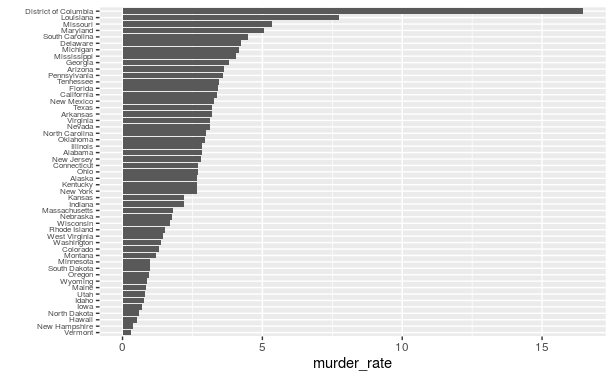

```r
data(murders)
murders %>% mutate(murder_rate = total / population * 100000) %>%
  mutate(state = reorder(state, murder_rate)) %>%
  ggplot(aes(state, murder_rate)) +
  geom_bar(stat="identity") +
  coord_flip() +
  theme(axis.text.y = element_text(size = 6)) +
  xlab("")
```

## **11.5 Show the data**

We now shift our attention to displaying data, with a focus on comparing groups.

This brings us to our first principle: show the data. This simple ggplot2 code already generates a more informative plot than the barplot by simply showing all the data points:

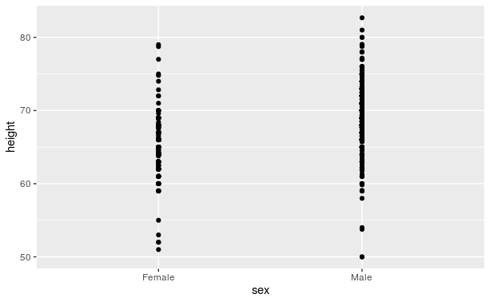

```r
heights %>%
  ggplot(aes(sex, height)) +
  geom_point()
```

For example, this plot gives us an idea of the range of the data. However, this plot has limitations as well, since we can’t really see all the 238 and 812 points plotted for females and males respectively, and many points are plotted on top of each other. As we have previously described, visualizing the distribution is much more informative.

The first is to add jitter, which adds a small random shift to each point. In this case, adding horizontal jitter does not alter the interpretation, since the point heights do not change, but we minimize the number of points that fall on top of each other and, therefore, get a better visual sense of how the data is distributed. A second improvement comes from using alpha blending: making the points somewhat transparent. The more points fall on top of each other, the darker the plot, which also helps us get a sense of how the points are distributed.

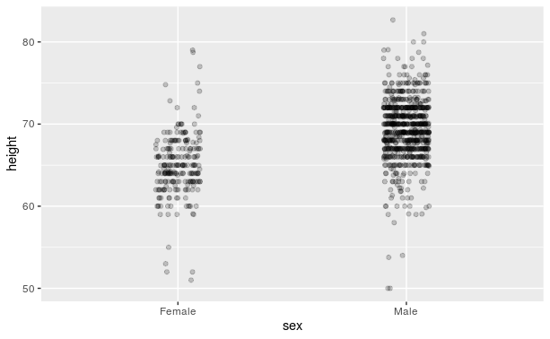

```r
heights %>%
  ggplot(aes(sex, height)) +
  geom_jitter(width = 0.1, alpha = 0.2)
```

Now we start getting a sense that, on average, males are taller than females.

## **11.6 Ease comparisons**

### **11.6.1 Use common axes**

Since there are so many points, it is more effective to show distributions rather than individual points. We therefore show histograms for each group.

An important principle here is to **keep the axes the same** when comparing data across to plots.

https://rafalab.github.io/dsbook/book_files/figure-html/common-axes-histograms-right-1.png

### **11.6.2 Align plots vertically to see horizontal chnages and horizontally to see vertical changes**

In these histograms, the visual cue related to decreases or increases in height are shifts to the left or right respectively: horizontal changes. Aligning the plots vertically helps us see this change when the axes are fixed:

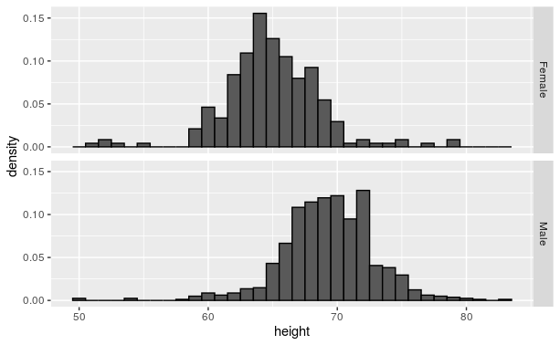

```r
heights %>%
  ggplot(aes(height, ..density..)) +
  geom_histogram(binwidth = 1, color='black') +
  facet_grid(sex~.)
```

If , we want the more compact summary provided by boxplots, we then align them horizontally since, by default, boxplots move up and down with changes in height.

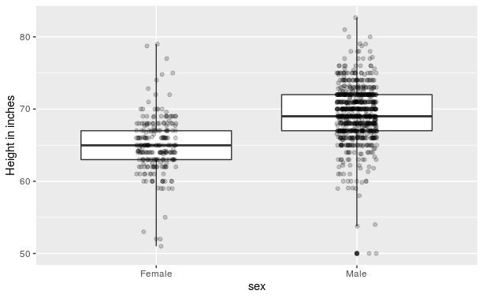

```r
 heights %>%
  ggplot(aes(sex, height)) +
  geom_boxplot(coef=3) +
  geom_jitter(width = 0.1, alpha = 0.2) +
  ylab("Height in inches")
```

*Remember*: Barplots are useful for showing one number, but not very useful when we want to describe distributions.

### **11.6.3 Consider transformations**

We have motivated the use of the log transformation in cases where the changes are multiplicative. Population size was an example in which we found a log transformation to yield a more informative transformation.

As an example, consider this barplot showing the average population sizes for each continent in 2015:

https://rafalab.github.io/dsbook/book_files/figure-html/no-transformations-wrong-use-of-barplot-1.png

From this plot, one would conclude that countries in Asia are much more populous than in other continents. Following the show the data principle, we quickly notice that this is due to two very large countries, which we assume are India and China:

https://rafalab.github.io/dsbook/book_files/figure-html/no-transformation-1.png

Using a log transformation here provides a much more informative plot. We compare the original barplot to a boxplot using the log scale transformation for the y-axis:

https://rafalab.github.io/dsbook/book_files/figure-html/correct-transformation-1.png

### **11.6.4 VIsual cues to be compared should be adjacent**

The default in ggplot2 is to order labels alphabetically so the labels with 1970 come before the labels with 2010, making the comparisons challenging because a continent’s distribution in 1970 is visually far from its distribution in 2010. It is much easier to make the comparison between 1970 and 2010 for each continent when the boxplots for that continent are next to each other:

https://rafalab.github.io/dsbook/book_files/figure-html/boxplot-adjacent-comps-1.png

### **11.6.5 Use color**

The comparison becomes even easier to make if we use color to denote the two things we want to compare:

https://rafalab.github.io/dsbook/book_files/figure-html/boxplot-adjacent-comps-with-color-1.png

## **11.7 Think of the color blind**

About 10% of the population is color blind. Unfortunately, the default colors used in ggplot2 are not optimal for this group. However, ggplot2 does make it easy to change the color palette used in the plots. An example of how we can use a color blind friendly palette is described here:

```r
color_blind_friendly_cols <-
  c("#999999", "#E69F00", "#56B4E9", "#009E73",
    "#F0E442", "#0072B2", "#D55E00", "#CC79A7")
```

https://rafalab.github.io/dsbook/book_files/figure-html/color-blind-friendly-colors-1.png

## **11.8 Plots for two variables**

In general, you should use scatterplots to visualize the relationship between two variables. However, there are some exceptions and we describe two alternative plots here: the *slope chart* and the *Bland-Altman plot*.

### **11.8.1 Slope charts**

One exception where another type of plot may be more informative is when you are comparing variables of the same type, but at different time points and for a relatively small number of comparisons.

There is no geometry for slope charts in ggplot2, but we can construct one using geom_line. We need to do some tinkering to add labels.

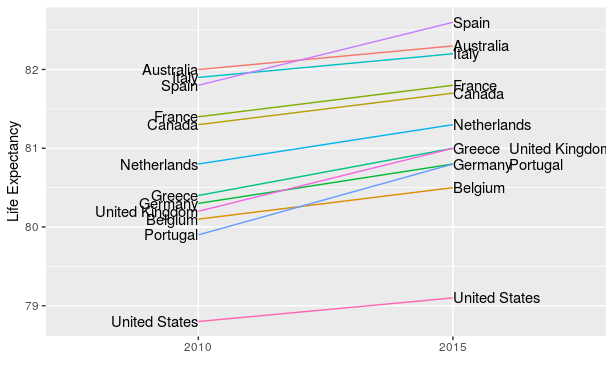

```r
west <- c("Western Europe","Northern Europe","Southern Europe",
          "Northern America","Australia and New Zealand")

dat <- gapminder %>%
  filter(year%in% c(2010, 2015) & region %in% west &
           !is.na(life_expectancy) & population > 10^7)

dat %>%
  mutate(location = ifelse(year == 2010, 1, 2),
         location = ifelse(year == 2015 &
                             country %in% c("United Kingdom","Portugal"),
                           location+0.22, location),
         hjust = ifelse(year == 2010, 1, 0)) %>%
  mutate(year = as.factor(year)) %>%
  ggplot(aes(year, life_expectancy, group = country)) +
  geom_line(aes(color = country), show.legend = FALSE) +
  geom_text(aes(x = location, label = country, hjust = hjust),
            show.legend = FALSE) +
  xlab("") +
  ylab("Life Expectancy")
```

An advantage of the slope chart is that it permits us to quickly get an idea of changes based on the slope of the lines. Although we are using angle as the visual cue, we also have position to determine the exact values.

### **11.8.2 Bland-Altman plot**

Since we are primarily interested in the difference, it makes sense to dedicate one of our axes to it. The Bland-Altman plot, also know as the Tukey mean-difference plot and the MA-plot, shows the difference versus the average:

[figure not shown]

```r
library(ggrepel)
dat %>%
   mutate(year = paste0("life_expectancy_", year)) %>%
   select(country, year, life_expectancy) %>% spread(year, life_expectancy) %>%
  mutate(average = (life_expectancy_2015 + life_expectancy_2010)/2,
         difference = life_expectancy_2015 - life_expectancy_2010) %>%
  ggplot(aes(average, difference, label = country)) +
  geom_point() +
  geom_text_repel() +
  geom_abline(lty = 2) +
  xlab("Average of 2010 and 2015") +
  ylab("Difference between 2015 and 2010")
```

Here, by simply looking at the y-axis, we quickly see which countries have shown the most improvement.

## **11.9 Encoding a third variable**

An earlier scatterplot showed the relationship between infant survival and average income. Below is a version of this plot that encodes three variables: OPEC membership, region and population.

https://rafalab.github.io/dsbook/book_files/figure-html/encoding-third-variable-1.png

We encode categorical variables with color and shape. These shapes can be controlled with `shape` argument. For continuous variables, we can use color, intensity or size.

When selecting colors to quantify a numeric variable, we choose between two options: sequential and diverging. Sequential colors are suited for data that goes from high to low. High values are clearly distinguished from low values. Here are some examples offered by the package `RColorBrewer`:

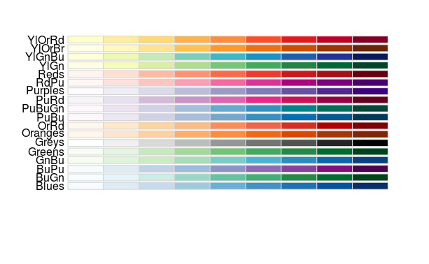

```r
library(RColorBrewer)
display.brewer.all(type="seq")
```

Diverging colors are used to represent values that diverge from a center. We put equal emphasis on both ends of the data range: higher than the center and lower than the center. An example of when we would use a divergent pattern would be if we were to show height in standard deviations away from the average. Here are some examples of divergent patterns:

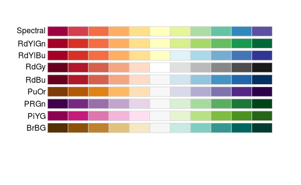

```r
library(RColorBrewer)
display.brewer.all(type="div")
```

## **11.10 Avoid pseudo-three-dimensional plots**

Humans are not good at seeing in three dimensions and our limitation is even worse with regard to pseudo-three-dimensions.

Pseudo-3D is sometimes used completely gratuitously: plots are made to look 3D even when the 3rd dimension does not represent a quantity. This only adds confusion and makes it harder to relay your message.

## **11.11 Avoid too many significant digits**

The default behavior in R is to show 7 significant digits. That many digits often adds no information and the added the visual clutter can make it hard for the viewer to understand the message.

Useful ways to change the number of significant digits or to round numbers are `signif` and `round`. You can define the number of significant digits globally by setting options like this: `options(digits = 3)`.

## **11.12 Know your audience**

Graphs can be used for

1. our own exploratory data analysis,
2. to convey a message to experts, or
3. to help tell a story to a general audience. Make sure that the intended audience understands each element of the plot.

## **11.13 Exercises**

```r
library(dslabs)
data(us_contagious_diseases)
```

**1. Pie charts are appropriate:**

B. When ggplot2 is not available.

C. When I am in a bakery.

D. Never. Barplots and tables are always better.

**2. What is the problem with the plot below:**

https://rafalab.github.io/dsbook/book_files/figure-html/baplot-not-from-zero-exercises-1.png

A. The values are wrong. The final vote was 306 to 232.

**B. The axis does not start at 0. Judging by the length, it appears Trump received 3 times as many votes when, in fact, it was about 30% more.**

C. The colors should be the same.

D. Percentages should be shown as a pie chart.

https://rafalab.github.io/dsbook/book_files/figure-html/measels-exercise-1.png

A. They provide the same information, so they are both equally as good.

B. The plot on the right is better because it orders the states alphabetically.

**C. The plot on the right is better because alphabetical order has nothing to do with the disease and by ordering according to actual rate, we quickly see the states with most and least rates.**

D. Both plots should be a pie chart.

**4. To make the plot on the left, we have to reorder the levels of the states’ variables.**

```r
dat <- us_contagious_diseases %>%
  filter(year == 1967 & disease=="Measles" & !is.na(population)) %>%
  mutate(rate = count / population * 10000 * 52 / weeks_reporting)
```

Note what happens when we make a barplot:

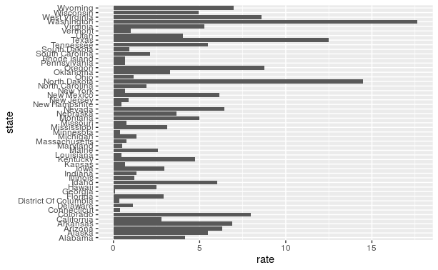

```r
dat %>% ggplot(aes(state, rate)) +
  geom_bar(stat="identity") +
  coord_flip()
```

Define these objects:

```r
state <- dat$state
rate <- dat$count/dat$population*10000*52/dat$weeks_reporting
```

**Redefine the `state` object so that the levels are re-ordered. Print the new object `state` and its levels so you can see that the vector is not re-ordered by the levels.**

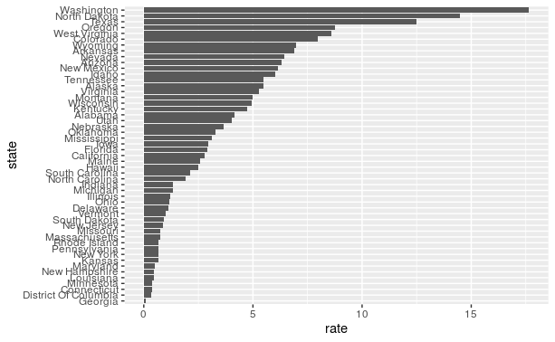

```r
dat %>%
  mutate(state = reorder(state, rate)) %>%
  ggplot(aes(state, rate)) +
  geom_bar(stat="identity") +
  coord_flip()
```

**5. Now with one line of code, define the `dat` table as done above, but change the use mutate to create a rate variable and reorder the state variable so that the levels are reordered by this variable. Then make a barplot using the code above, but for this new `dat`.**

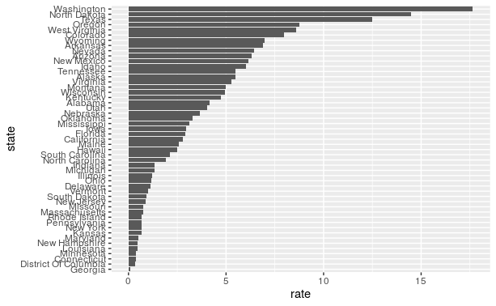

```r
dat %>%
  mutate(state = reorder(state, rate)) %>%
  ggplot(aes(state, rate)) +
  geom_bar(stat="identity") +
  coord_flip()
```

6. Say we are interested in comparing gun homicide rates across regions of the US and decide to move to a state in the western region. What is the main problem with this interpretation?

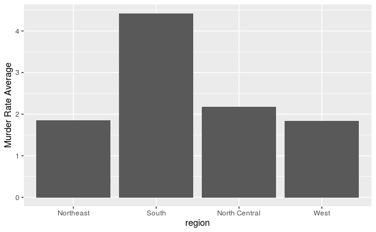

```r
library(dslabs)
data("murders")
murders %>% mutate(rate = total/population*100000) %>%
  group_by(region) %>%
  summarize(avg = mean(rate)) %>%
  mutate(region = factor(region)) %>%
  ggplot(aes(region, avg)) +
  geom_bar(stat="identity") +
  ylab("Murder Rate Average")
```

A. The categories are ordered alphabetically.

B. The graph does not show standard errors.

**C. It does not show all the data. We do not see the variability within a region and it’s possible that the safest states are not in the West.**

D. The Northeast has the lowest average.

**7. Make a boxplot of the murder rates defined as**

```r
data("murders")
murders %>% mutate(rate = total/population*100000)
```

| state | abb | region | population | total | rate |
| --- | --- | --- | --- | --- | --- |
| Alabama | AL | South | 4779736 | 135 | 2.8244238 |
| Alaska | AK | West | 710231 | 19 | 2.6751860 |
| Arizona | AZ | West | 6392017 | 232 | 3.6295273 |
| Arkansas | AR | South | 2915918 | 93 | 3.1893901 |
| California | CA | West | 37253956 | 1257 | 3.3741383 |
| Colorado | CO | West | 5029196 | 65 | 1.2924531 |
| Connecticut | CT | Northeast | 3574097 | 97 | 2.7139722 |
| Delaware | DE | South | 897934 | 38 | 4.2319369 |
| District of Columbia | DC | South | 601723 | 99 | 16.4527532 |
| Florida | FL | South | 19687653 | 669 | 3.3980688 |

[output cut: 41 more lines]

**by region, showing all the points and ordering the regions by their median rate.**

[figure not shown]

```r
murders %>%
  mutate(region = reorder(region, rate)) %>%
  ggplot(aes(region, rate)) +
  geom_boxplot(coef=3) +
  geom_jitter(width=0.1, alpha=0.3)
```

**8. The plots below show three continuous variables.**

https://rafalab.github.io/dsbook/book_files/figure-html/pseudo-3d-exercise-1.png

The line *x=2* appears to separate the points. But it is actually not the case, which we can see by plotting the data in a couple of two dimensional points. Why is this happening?

https://rafalab.github.io/dsbook/book_files/figure-html/pseud-3d-exercise-2-1.png

A. Humans are not good at reading pseudo-3D plots.

B. There must be an error in the code.

C. The colors confuse us.

**9. Reproduce the image plot we previously made but for smallpox. For this plot, do not include years in which cases were not reported in 10 or more weeks.**

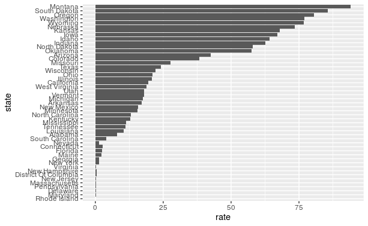

```r
dat <- us_contagious_diseases %>%
  filter(weeks_reporting > 10 & disease=="Smallpox" & !is.na(population)) %>%
  mutate(rate = count / population * 10000 * 52 / weeks_reporting)

state <- dat$state
rate <- dat$count/dat$population*10000*52/dat$weeks_reporting

dat %>%
  mutate(state = reorder(state, rate)) %>%
  ggplot(aes(state, rate)) +
  geom_bar(stat="identity") +
  coord_flip()
```

**10. Now reproduce the time series plot we previously made, but this time following the instructions of the previous question.**

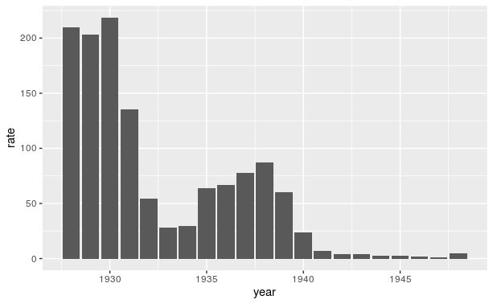

```r
dat %>%
  ggplot(aes(year, rate)) +
  geom_bar(stat="identity")
```

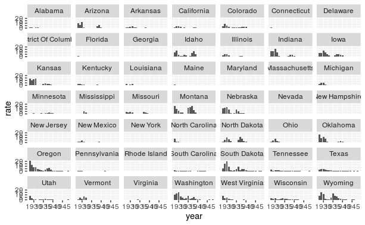

```r
dat %>%
  ggplot(aes(year, rate)) +
  geom_bar(stat="identity") +
  facet_wrap(state~.)
```

**11. For the state of California, make a time series plots showing rates for all diseases. Include only years with 10 or more weeks reporting. Use a different color for each disease.**

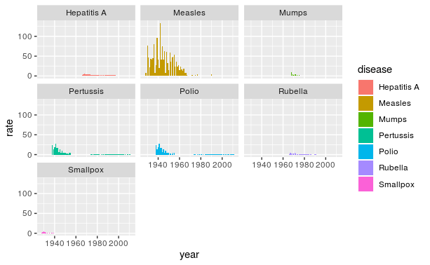

```r
us_contagious_diseases %>%
  filter(weeks_reporting > 10 & state=="California" & !is.na(population)) %>%
  mutate(rate = count / population * 10000 * 52 / weeks_reporting) %>%
  ggplot(aes(year, rate, fill=disease)) +
  geom_bar(stat='identity') +
  facet_wrap(disease~.)
```

**12. Now do the same for the rates for the US. Hint: compute the US rate by using summarize, the total divided by total population.**

```r
us_contagious_diseases %>%
  summarize(total=sum(count), total_pop=sum(population))
```

| total | total_pop |
| --- | --- |
| 25805302 | NA |

## **11.14 Case study: impact of vaccines on battling infectious diseases**

Effective communication of data is a strong antidote to misinformation and fear-mongering. Earlier we used an example provided by a Wall Street Journal article showing data related to the impact of vaccines on battling infectious diseases. Here we reconstruct that example.

```r
library(tidyverse)
library(dslabs)
data(us_contagious_diseases)
str(us_contagious_diseases)
```

```
'data.frame':   18870 obs. of  6 variables:
 $ disease        : Factor w/ 7 levels "Hepatitis A",..: 1 1 1 1 1 1 1 1 1 1 ...
 $ state          : Factor w/ 51 levels "Alabama","Alaska",..: 1 1 1 1 1 1 1 1 1 1 ...
 $ year           : num  1966 1967 1968 1969 1970 ...
 $ weeks_reporting: int  50 49 52 49 51 51 45 45 45 46 ...
 $ count          : num  321 291 314 380 413 378 342 467 244 286 ...
 $ population     : num  3345787 3364130 3386068 3412450 3444165 ...
```

Note that there is a `weeks_reporting` column that tells us for how many weeks of the year data was reported. We have to adjust for that value when computing the rate.

```r
the_disease <- "Measles"
dat <- us_contagious_diseases %>%
  filter(!state%in%c("Hawaii","Alaska") & disease == the_disease) %>%
  mutate(rate = count / population * 10000 * 52 / weeks_reporting) %>%
  mutate(state = reorder(state, rate))
```

We can now easily plot disease rates per year. Here are the measles data from California:

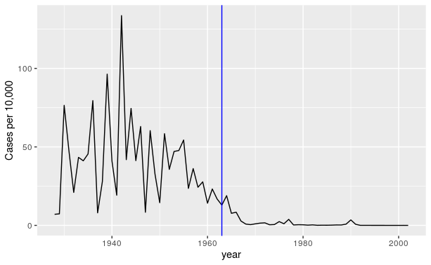

```r
dat %>% filter(state == "California" & !is.na(rate)) %>%
  ggplot(aes(year, rate)) +
  geom_line() +
  ylab("Cases per 10,000")  +
  geom_vline(xintercept=1963, col = "blue")
```

We add a vertical line at 1963 since this is when the vaccine was introduced.

In our example, we want to use a sequential palette since there is no meaningful center, just low and high rates.

We use the geometry `geom_tile` to tile the region with colors representing disease rates. We use a square root transformation to avoid having the really high counts dominate the plot.

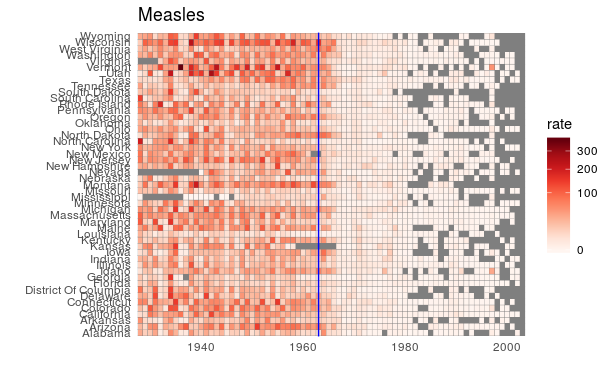

```r
dat %>%
  ggplot(aes(year, state, fill = rate)) +
  geom_tile(color = "grey50") +
  scale_x_continuous(expand=c(0,0)) +
  scale_fill_gradientn(colors = RColorBrewer::brewer.pal(9, "Reds"), trans = "sqrt") +
  geom_vline(xintercept=1963, col = "blue") +
  theme_minimal() +  theme(panel.grid = element_blank()) +
  ggtitle(the_disease) +
  ylab("") +
  xlab("")
```

This plot makes a very striking argument for the contribution of vaccines. However, one limitation of this plot is that it uses color to represent quantity, which we earlier explained makes it harder to know exactly how high values are going.

```r
avg <- us_contagious_diseases %>%
  filter(disease==the_disease) %>% group_by(year) %>%
  summarize(us_rate = sum(count, na.rm=TRUE)/sum(population, na.rm=TRUE)*10000)
```

Now to make the plot we simply use the `geom_line` geometry:

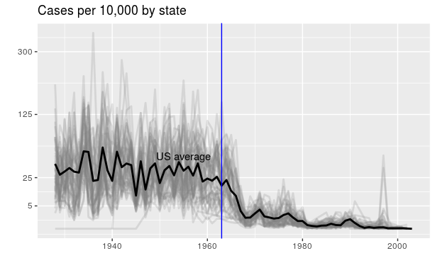

```r
dat %>%
  filter(!is.na(rate)) %>%
  ggplot() +
  geom_line(aes(year, rate, group = state),  color = "grey50",
            show.legend = FALSE, alpha = 0.2, size = 1) +
  geom_line(mapping = aes(year, us_rate),  data = avg, size = 1, color = "black") +
  scale_y_continuous(trans = "sqrt", breaks = c(5, 25, 125, 300)) +
  ggtitle("Cases per 10,000 by state") +
  xlab("") +
  ylab("") +
  geom_text(data = data.frame(x = 1955, y = 50),
            mapping = aes(x, y, label="US average"),
            color="black") +
  geom_vline(xintercept=1963, col = "blue")
```